# Interspeech 2019

Jalal Al-Tamimi

Newcastle University

04 April 2019

# 1 Introduction

This notebook describes the analyses presented in the paper: **Al-Tamimi, J. (under review). *Acoustic correlates of an epilaryngeal constriction in Levantine Arabic Guttural consonants*. Interpseech 2019, Graz - Austria**.

# 2 Loading packages

```r
requiredPackages = c('dplyr','DMwR','party','tidyverse','ggplot2','reshape2','phonR','knitr','lmerTest','FactoMineR','factoextra','RColorBrewer','scatterplot3d')
for(p in requiredPackages){
  if(!require(p,character.only = TRUE)) install.packages(p)
  library(p,character.only = TRUE)
}
```

# 3 Description of the dataset

This data is obtained from ten speakers producing various consonants in the frame VCV, with V = symmetric /i: a: u:/ (=vowel) and C is one of 22 consonants put into six categories: “plain”, “velar”, “uvular”, “pharyngealised”, “pharyngeal” and glottal (=context). The data is from audio recordings synchronised with ultrasound tongue imaging, and electroglottography (with larynx constriction and height). For the current acoustic data, we have obtained voice quality measures and formant frequencies from the software VoiceSauce by using the parameters from Praat (for f0 and formant estimation). The current analyses are on voice quality metrics. After obtaining the data from VoiceSauce, manual data verification took place by visualising a spectrogram and looking at the patterns in the data. Formant frequencies were adapted to each speaker and vowel context (for the back vowel /u:/, we used another set of formant ceiling). F0 data were speaker adapted by estimating the range of each speaker before applying data extraction.

Once the data was verified, we obtained 11 points of measurements in each of the vowels preceding and following (V1 and V2 respectively) the consonant of interest. Below we present the data for each of V1 and V2.

A total of 66 words (=word) were obtained and these were repeated 3 times. The outcome is each acoustic measure, and the predictors are context and vowel, and the random factors are speaker and word. We also evaluate (at a later stage) the role of the sex of the speaker in evaluating differences.

# 4 Data manipulation

## 4.1 Importing the dataframe and checking structure

```r
resultsIntFull <- read.csv("acoustics_all_speakers_Intervals.csv")
str(resultsIntFull)
```

```
'data.frame':   10159 obs. of  543 variables:
 $ Speaker           : Factor w/ 10 levels "SP01","SP02",..: 1 1 1 1 1 1 1 1 1 1 ...
 $ Sex               : Factor w/ 2 levels "Female","Male": 2 2 2 2 2 2 2 2 2 2 ...
 $ WordRep           : Factor w/ 198 levels "2aa2aa_1","2aa2aa_2",..: 49 49 49 49 49 51 51 51 51 51 ...
 $ targetWord        : Factor w/ 66 levels "2aa2aa","2aa3aa",..: 17 17 17 17 17 17 17 17 17 17 ...
 $ wordNumber        : Factor w/ 66 levels "Word1","Word10",..: 1 1 1 1 1 1 1 1 1 1 ...
 $ repetition        : Factor w/ 3 levels "rep01","rep02",..: 1 1 1 1 1 2 2 2 2 2 ...
 $ mannerArticulation: Factor w/ 3 levels "Fricative","Lateral",..: 3 3 3 3 3 3 3 3 3 3 ...
 $ voicing           : Factor w/ 2 levels "Voiced","Voiceless": 2 2 2 2 2 2 2 2 2 2 ...
 $ context           : Factor w/ 6 levels "Glottal","Pharyngeal",..: 4 4 4 4 4 4 4 4 4 4 ...
 $ cons              : Factor w/ 22 levels "2","3","d","D",..: 17 17 17 17 17 17 17 17 17 17 ...
 $ vowel             : Factor w/ 3 levels "a:","i:","u:": 1 1 1 1 1 1 1 1 1 1 ...
 $ Phoneme           : Factor w/ 26 levels "(h)","?","?-",..: 2 4 19 4 1 2 4 19 4 1 ...
 $ Label             : Factor w/ 5 levels "C1","C2","C3",..: 1 4 2 5 3 1 4 2 5 3 ...
 $ seg_Start         : num  85.5 133.6 268.5 408.9 584.8 ...
```

[output cut: 86 more lines]

## 4.2 Data manipulation

### 4.2.1 Creating new variables

We create new variables for bark differences and amplitude differences within the original dataset

```r
dfPharRFV2.O <- resultsIntFull
#Z1-Z0
dfPharRFV2.O$Z1mnZ0_01 <- dfPharRFV2.O$F1Bark_01-dfPharRFV2.O$F0Bark_01
#Z2-Z1
dfPharRFV2.O$Z2mnZ1_01 <- dfPharRFV2.O$F2Bark_01-dfPharRFV2.O$F1Bark_01
#Z3-Z2
dfPharRFV2.O$Z3mnZ2_01 <- dfPharRFV2.O$F3Bark_01-dfPharRFV2.O$F2Bark_01
#A1-A2
dfPharRFV2.O$A1mnA2_01 <- dfPharRFV2.O$A1c_01-dfPharRFV2.O$A2c_01
#A1-A3
dfPharRFV2.O$A1mnA3_01 <- dfPharRFV2.O$A1c_01-dfPharRFV2.O$A3c_01
#A2-A3
dfPharRFV2.O$A2mnA3_01 <- dfPharRFV2.O$A2c_01-dfPharRFV2.O$A3c_01
```

### 4.2.2 Subsets of data

```r
levels(dfPharRFV2.O$context)
```

```
[1] "Glottal"        "Pharyngeal"     "Pharyngealised"
[4] "Plain"          "Uvular"         "Velar"
```

```r
dfPharRFV2.O$context <- factor(dfPharRFV2.O$context, levels=c("Plain","Velar","Uvular","Pharyngeal","Pharyngealised","Glottal"))
levels(dfPharRFV2.O$context)
```

```
[1] "Plain"          "Velar"          "Uvular"
[4] "Pharyngeal"     "Pharyngealised" "Glottal"
```

```r
levels(dfPharRFV2.O$vowel)
```

```
[1] "a:" "i:" "u:"
```

```r
dfPharRFV2.O$vowel <- factor(dfPharRFV2.O$vowel,levels=c("i:","a:","u:"))
levels(dfPharRFV2.O$vowel)
```

```
[1] "i:" "a:" "u:"
```

```r
dfPharRFSubV2 <- subset(dfPharRFV2.O, Label=="V2")
str(dfPharRFSubV2)
```

```
'data.frame':   2034 obs. of  549 variables:
 $ Speaker           : Factor w/ 10 levels "SP01","SP02",..: 1 1 1 1 1 1 1 1 1 1 ...
 $ Sex               : Factor w/ 2 levels "Female","Male": 2 2 2 2 2 2 2 2 2 2 ...
 $ WordRep           : Factor w/ 198 levels "2aa2aa_1","2aa2aa_2",..: 49 51 53 7 9 11 50 52 54 8 ...
 $ targetWord        : Factor w/ 66 levels "2aa2aa","2aa3aa",..: 17 17 17 3 3 3 18 18 18 4 ...
 $ wordNumber        : Factor w/ 66 levels "Word1","Word10",..: 1 1 1 12 12 12 23 23 23 34 ...
 $ repetition        : Factor w/ 3 levels "rep01","rep02",..: 1 2 3 1 2 3 1 2 3 1 ...
 $ mannerArticulation: Factor w/ 3 levels "Fricative","Lateral",..: 3 3 3 3 3 3 3 3 3 3 ...
 $ voicing           : Factor w/ 2 levels "Voiced","Voiceless": 2 2 2 1 1 1 2 2 2 1 ...
 $ context           : Factor w/ 6 levels "Plain","Velar",..: 1 1 1 1 1 1 5 5 5 5 ...
 $ cons              : Factor w/ 22 levels "2","3","d","D",..: 17 17 17 3 3 3 18 18 18 4 ...
 $ vowel             : Factor w/ 3 levels "i:","a:","u:": 2 2 2 2 2 2 2 2 2 2 ...
 $ Phoneme           : Factor w/ 26 levels "(h)","?","?-",..: 4 4 4 4 4 4 4 4 4 4 ...
 $ Label             : Factor w/ 5 levels "C1","C2","C3",..: 5 5 5 5 5 5 5 5 5 5 ...
 $ seg_Start         : num  409 416 378 406 396 ...
```

[output cut: 86 more lines]

### 4.2.3 Central imputation

Some of the variables in the dataset are empty (total is less than 10). To allow us using Random Forests in an appropriate way, we cannot have empty cases. We use the package `DMwR` for central imputations of the missing data.

```r
# Central imputation using the package "DMwR".
dfPharRFSubV2[, 16:549] <- centralImputation(dfPharRFSubV2[, 16:549])
```

### 4.2.4 Z-scoring of the data

The data we have here comes from a variety of correlates that differ in their scales. To allow for a meaningful interpretation of the results, we z-score the data to put all predictors on the same level

```r
# from the package "dplyr"
# V2
all_z <- select(dfPharRFSubV2, H1c_01:A2mnA3_01)
all_z <- cbind(all_z, select(dfPharRFSubV2))
all_z <- apply(all_z, 2, scale)
colnames(all_z) <- paste(colnames(all_z), 'z', sep = '_')
dfPharRFSubV2 <- cbind(dfPharRFSubV2, all_z)
```

# 5 Linear Mixed effects Modelling

We use Linear Mixed effects Modelling in a confirmatory way to evaluate the differences between the 6 contexts with respect to each of the predictors. We will look at five predictors only that were reported in the paper. The remaining data will be evaluated further in a future publication

## 5.1 Z2-Z1

### 5.1.1 Model Specification

#### 5.1.1.1 Full Model

```r
mdl.V2Z2Z1.Full <- lmer(Z2mnZ1_01~context+vowel+Sex+(context+vowel||Speaker)+
                          (1|targetWord),data=dfPharRFSubV2,
                        control = lmerControl(optimizer = "bobyqa",optCtrl=list(maxfun=1e5)))
```

#### 5.1.1.2 Null Model

```r
mdl.V2Z2Z1.Null <- lmer(Z2mnZ1_01~vowel+Sex+(vowel||Speaker)+
                          (1|targetWord),data=dfPharRFSubV2,
                        control = lmerControl(optimizer = "bobyqa",optCtrl=list(maxfun=1e5)))
```

### 5.1.2 Model Comparison

```r
anova(mdl.V2Z2Z1.Null,mdl.V2Z2Z1.Full)
```

```
Data: dfPharRFSubV2
Models:
mdl.V2Z2Z1.Null: Z2mnZ1_01 ~ vowel + Sex + (vowel || Speaker) + (1 | targetWord)
mdl.V2Z2Z1.Full: Z2mnZ1_01 ~ context + vowel + Sex + (context + vowel || Speaker) +
mdl.V2Z2Z1.Full:     (1 | targetWord)
                Df    AIC    BIC  logLik deviance  Chisq Chi Df
mdl.V2Z2Z1.Null 13 5088.4 5161.5 -2531.2   5062.4
mdl.V2Z2Z1.Full 39 4644.8 4863.9 -2283.4   4566.8 495.65     26
                Pr(>Chisq)
mdl.V2Z2Z1.Null
mdl.V2Z2Z1.Full  < 2.2e-16 ***
---
Signif. codes:  0 ‘***’ 0.001 ‘**’ 0.01 ‘*’ 0.05 ‘.’ 0.1 ‘ ’ 1
```

### 5.1.3 Summary

```r
summary(mdl.V2Z2Z1.Full)
```

```
Linear mixed model fit by REML. t-tests use Satterthwaite's
  method [lmerModLmerTest]
Formula:
Z2mnZ1_01 ~ context + vowel + Sex + (context + vowel || Speaker) +
    (1 | targetWord)
   Data: dfPharRFSubV2
Control:
lmerControl(optimizer = "bobyqa", optCtrl = list(maxfun = 1e+05))

REML criterion at convergence: 4572.2

Scaled residuals:
    Min      1Q  Median      3Q     Max
-3.8369 -0.5944 -0.0400  0.6078  7.9809

Random effects:
 Groups     Name                  Variance Std.Dev. Corr
 targetWord (Intercept)           1.08286  1.0406
 Speaker    voweli:               0.05415  0.2327
            vowela:               0.03956  0.1989   -0.99
            vowelu:               0.19028  0.4362   -0.71  0.79
 Speaker.1  contextPlain          0.04282  0.2069
            contextVelar          0.03091  0.1758   -0.16
            contextUvular         0.42903  0.6550    0.17  0.62
            contextPharyngeal     0.06706  0.2590    0.34  0.70
            contextPharyngealised 0.69866  0.8359    0.02  0.95
            contextGlottal        0.03110  0.1764    0.31 -0.07
 Speaker.2  (Intercept)           0.00000  0.0000
 Residual                         0.45396  0.6738








  0.16
  0.83  0.59
  0.47 -0.34  0.16
```

[output cut: 32 more lines]

```
contxtPhryngl -0.358  0.304  0.165
cntxtPhryngls -0.419  0.419  0.339  0.316
contxtGlttl   -0.364  0.292  0.176  0.216         0.271
vowela:       -0.561  0.000  0.000  0.000         0.000
vowelu:       -0.541  0.000  0.000  0.000         0.000
SexMale       -0.105  0.001  0.000  0.000         0.001
              cntxtG vowela: vowelu:
contextVelr
contextUvlr
contxtPhryngl
cntxtPhryngls
contxtGlttl
vowela:        0.000
vowelu:        0.000  0.578
SexMale        0.000  0.000   0.000
```

### 5.1.4 Pairwise comparison

```r
pairwise.t.test(predict(mdl.V2Z2Z1.Full),
                dfPharRFSubV2$context:dfPharRFSubV2$vowel, p.adj = "fdr")
```

```
    Pairwise comparisons using t tests with pooled SD

data:  predict(mdl.V2Z2Z1.Full) and dfPharRFSubV2$context:dfPharRFSubV2$vowel

                  Plain:i: Plain:a: Plain:u: Velar:i: Velar:a:
Plain:a:          < 2e-16  -        -        -        -
Plain:u:          < 2e-16  0.03326  -        -        -
Velar:i:          0.47005  < 2e-16  < 2e-16  -        -
Velar:a:          < 2e-16  0.04607  0.85196  < 2e-16  -
Velar:u:          < 2e-16  < 2e-16  < 2e-16  < 2e-16  < 2e-16
Uvular:i:         < 2e-16  < 2e-16  < 2e-16  < 2e-16  < 2e-16
Uvular:a:         < 2e-16  < 2e-16  < 2e-16  < 2e-16  < 2e-16
Uvular:u:         < 2e-16  < 2e-16  < 2e-16  < 2e-16  < 2e-16
Pharyngeal:i:     < 2e-16  < 2e-16  < 2e-16  < 2e-16  < 2e-16
Pharyngeal:a:     < 2e-16  < 2e-16  < 2e-16  < 2e-16  < 2e-16
Pharyngeal:u:     < 2e-16  < 2e-16  < 2e-16  < 2e-16  < 2e-16
Pharyngealised:i: < 2e-16  1.4e-10  1.2e-05  < 2e-16  0.00035
Pharyngealised:a: < 2e-16  < 2e-16  < 2e-16  < 2e-16  < 2e-16
Pharyngealised:u: < 2e-16  < 2e-16  < 2e-16  < 2e-16  < 2e-16
Glottal:i:        0.00389  < 2e-16  < 2e-16  0.00133  < 2e-16
Glottal:a:        < 2e-16  < 2e-16  < 2e-16  < 2e-16  < 2e-16
Glottal:u:        < 2e-16  < 2e-16  < 2e-16  < 2e-16  < 2e-16
                  Velar:u: Uvular:i: Uvular:a: Uvular:u:
Plain:a:          -        -         -         -
Plain:u:          -        -         -         -
Velar:i:          -        -         -         -
Velar:a:          -        -         -         -
Velar:u:          -        -         -         -
Uvular:i:         < 2e-16  -         -         -
Uvular:a:         0.71160  < 2e-16   -         -
Uvular:u:         5.7e-06  < 2e-16   1.0e-04   -
Pharyngeal:i:     < 2e-16  0.00133   < 2e-16   < 2e-16
Pharyngeal:a:     1.8e-07  < 2e-16   5.4e-05   0.65277
Pharyngeal:u:     1.9e-05  < 2e-16   0.00693   1.1e-12
Pharyngealised:i: < 2e-16  8.1e-11   < 2e-16   < 2e-16
Pharyngealised:a: < 2e-16  < 2e-16   8.0e-10   < 2e-16
Pharyngealised:u: < 2e-16  < 2e-16   1.2e-15   < 2e-16
Glottal:i:        < 2e-16  < 2e-16   < 2e-16   < 2e-16
Glottal:a:        2.0e-14  < 2e-16   3.4e-07   < 2e-16
Glottal:u:        0.07724  < 2e-16   0.11176   0.00389
```

[output cut: 41 more lines]

```
Velar:u:          -                 -          -
Uvular:i:         -                 -          -
Uvular:a:         -                 -          -
Uvular:u:         -                 -          -
Pharyngeal:i:     -                 -          -
Pharyngeal:a:     -                 -          -
Pharyngeal:u:     -                 -          -
Pharyngealised:i: -                 -          -
Pharyngealised:a: -                 -          -
Pharyngealised:u: -                 -          -
Glottal:i:        < 2e-16           -          -
Glottal:a:        0.00359           < 2e-16    -
Glottal:u:        < 2e-16           < 2e-16    6.2e-16

P value adjustment method: fdr
```

## 5.2 Z3-Z2

### 5.2.1 Model Specification

#### 5.2.1.1 Full Model

```r
mdl.V2Z3Z2.Full <- lmer(Z3mnZ2_01~context+vowel+Sex+(context+vowel||Speaker)+
                          (1|targetWord),data=dfPharRFSubV2,
                        control = lmerControl(optimizer = "bobyqa",optCtrl=list(maxfun=1e5)))
```

#### 5.2.1.2 Null Model

```r
mdl.V2Z3Z2.Null <- lmer(Z3mnZ2_01~vowel+Sex+(vowel||Speaker)+
                          (1|targetWord),data=dfPharRFSubV2,
                        control = lmerControl(optimizer = "bobyqa",optCtrl=list(maxfun=1e5)))
```

### 5.2.2 Model Comparison

```r
anova(mdl.V2Z3Z2.Null,mdl.V2Z3Z2.Full)
```

```
Data: dfPharRFSubV2
Models:
mdl.V2Z3Z2.Null: Z3mnZ2_01 ~ vowel + Sex + (vowel || Speaker) + (1 | targetWord)
mdl.V2Z3Z2.Full: Z3mnZ2_01 ~ context + vowel + Sex + (context + vowel || Speaker) +
mdl.V2Z3Z2.Full:     (1 | targetWord)
                Df    AIC    BIC  logLik deviance  Chisq Chi Df
mdl.V2Z3Z2.Null 13 5179.2 5252.2 -2576.6   5153.2
mdl.V2Z3Z2.Full 39 4609.0 4828.1 -2265.5   4531.0 622.24     26
                Pr(>Chisq)
mdl.V2Z3Z2.Null
mdl.V2Z3Z2.Full  < 2.2e-16 ***
---
Signif. codes:  0 ‘***’ 0.001 ‘**’ 0.01 ‘*’ 0.05 ‘.’ 0.1 ‘ ’ 1
```

### 5.2.3 Summary

```r
summary(mdl.V2Z3Z2.Full)
```

```
Linear mixed model fit by REML. t-tests use Satterthwaite's
  method [lmerModLmerTest]
Formula:
Z3mnZ2_01 ~ context + vowel + Sex + (context + vowel || Speaker) +
    (1 | targetWord)
   Data: dfPharRFSubV2
Control:
lmerControl(optimizer = "bobyqa", optCtrl = list(maxfun = 1e+05))

REML criterion at convergence: 4537.8

Scaled residuals:
    Min      1Q  Median      3Q     Max
-8.3717 -0.5541 -0.0107  0.5415  4.3629

Random effects:
 Groups     Name                  Variance Std.Dev. Corr
 targetWord (Intercept)           0.711905 0.84374
 Speaker    voweli:               0.258853 0.50878
            vowela:               0.328933 0.57353   0.63
            vowelu:               0.009607 0.09801  -0.99 -0.72
 Speaker.1  contextPlain          0.045364 0.21299
            contextVelar          0.127530 0.35711   0.12
            contextUvular         0.483209 0.69513  -0.04  0.39
            contextPharyngeal     0.161135 0.40142   0.80  0.62
            contextPharyngealised 0.984602 0.99227   0.19  0.77
            contextGlottal        0.015394 0.12407   0.54  0.66
 Speaker.2  (Intercept)           0.000000 0.00000
 Residual                         0.444298 0.66656








  0.40
  0.69  0.59
 -0.08  0.74  0.19
```

[output cut: 32 more lines]

```
contxtPhryngl -0.269  0.300  0.190
cntxtPhryngls -0.285  0.449  0.351  0.311
contxtGlttl   -0.317  0.300  0.164  0.215         0.219
vowela:       -0.459  0.000  0.000  0.000         0.000
vowelu:       -0.669  0.000  0.000  0.000         0.000
SexMale       -0.140  0.000  0.000 -0.001         0.000
              cntxtG vowela: vowelu:
contextVelr
contextUvlr
contxtPhryngl
cntxtPhryngls
contxtGlttl
vowela:        0.000
vowelu:        0.000  0.435
SexMale        0.000  0.000   0.000
```

### 5.2.4 Pairwise comparison

```r
pairwise.t.test(predict(mdl.V2Z3Z2.Full),
                dfPharRFSubV2$context:dfPharRFSubV2$vowel, p.adj = "fdr")
```

```
    Pairwise comparisons using t tests with pooled SD

data:  predict(mdl.V2Z3Z2.Full) and dfPharRFSubV2$context:dfPharRFSubV2$vowel

                  Plain:i: Plain:a: Plain:u: Velar:i: Velar:a:
Plain:a:          < 2e-16  -        -        -        -
Plain:u:          < 2e-16  3.3e-13  -        -        -
Velar:i:          9.2e-05  < 2e-16  < 2e-16  -        -
Velar:a:          < 2e-16  3.1e-08  < 2e-16  < 2e-16  -
Velar:u:          < 2e-16  < 2e-16  < 2e-16  < 2e-16  < 2e-16
Uvular:i:         < 2e-16  1.5e-07  < 2e-16  < 2e-16  0.05072
Uvular:a:         < 2e-16  < 2e-16  < 2e-16  < 2e-16  < 2e-16
Uvular:u:         < 2e-16  < 2e-16  < 2e-16  < 2e-16  < 2e-16
Pharyngeal:i:     1.6e-11  < 2e-16  < 2e-16  0.00063  < 2e-16
Pharyngeal:a:     < 2e-16  0.01367  0.01947  < 2e-16  3.9e-10
Pharyngeal:u:     < 2e-16  < 2e-16  < 2e-16  < 2e-16  < 2e-16
Pharyngealised:i: < 2e-16  < 2e-16  0.03380  < 2e-16  < 2e-16
Pharyngealised:a: < 2e-16  < 2e-16  < 2e-16  < 2e-16  < 2e-16
Pharyngealised:u: < 2e-16  < 2e-16  < 2e-16  < 2e-16  < 2e-16
Glottal:i:        0.77331  < 2e-16  < 2e-16  0.01142  < 2e-16
Glottal:a:        < 2e-16  0.02281  0.01154  < 2e-16  1.2e-09
Glottal:u:        < 2e-16  < 2e-16  < 2e-16  < 2e-16  < 2e-16
                  Velar:u: Uvular:i: Uvular:a: Uvular:u:
Plain:a:          -        -         -         -
Plain:u:          -        -         -         -
Velar:i:          -        -         -         -
Velar:a:          -        -         -         -
Velar:u:          -        -         -         -
Uvular:i:         < 2e-16  -         -         -
Uvular:a:         < 2e-16  < 2e-16   -         -
Uvular:u:         1.5e-06  < 2e-16   < 2e-16   -
Pharyngeal:i:     < 2e-16  3.0e-12   < 2e-16   < 2e-16
Pharyngeal:a:     < 2e-16  6.4e-10   < 2e-16   < 2e-16
Pharyngeal:u:     < 2e-16  < 2e-16   0.03391   < 2e-16
Pharyngealised:i: < 2e-16  < 2e-16   < 2e-16   < 2e-16
Pharyngealised:a: < 2e-16  < 2e-16   0.74905   < 2e-16
Pharyngealised:u: < 2e-16  < 2e-16   3.6e-05   < 2e-16
Glottal:i:        < 2e-16  < 2e-16   < 2e-16   < 2e-16
Glottal:a:        < 2e-16  1.4e-09   < 2e-16   < 2e-16
Glottal:u:        0.43250  < 2e-16   < 2e-16   0.00013
```

[output cut: 41 more lines]

```
Velar:u:          -                 -          -
Uvular:i:         -                 -          -
Uvular:a:         -                 -          -
Uvular:u:         -                 -          -
Pharyngeal:i:     -                 -          -
Pharyngeal:a:     -                 -          -
Pharyngeal:u:     -                 -          -
Pharyngealised:i: -                 -          -
Pharyngealised:a: -                 -          -
Pharyngealised:u: -                 -          -
Glottal:i:        < 2e-16           -          -
Glottal:a:        < 2e-16           < 2e-16    -
Glottal:u:        1.1e-14           < 2e-16    < 2e-16

P value adjustment method: fdr
```

### 5.2.5 Figure

Rather than plotting the results in boxplot (as what we will do next), we use the package `phonR` to plot a two-dimensional vowel space with Z3-Z2 on the x-axis and Z2-Z1 on the y-axis

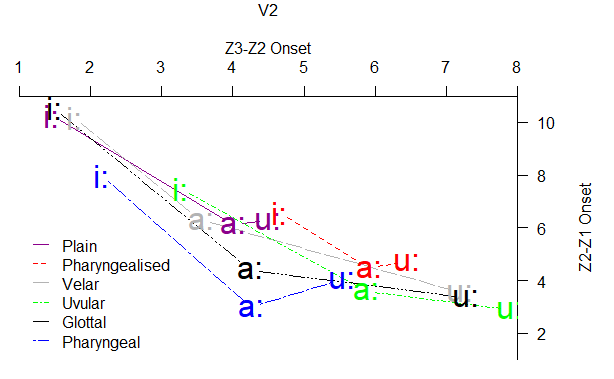

```r
with(dfPharRFSubV2, plotVowels(predict(mdl.V2Z2Z1.Full), predict(mdl.V2Z3Z2.Full), vowel, group = context, plot.tokens = FALSE, plot.means = TRUE,
                                         pch.means = vowel, cex.means = 2, var.col.by = context, var.sty.by = context,ellipse.fill = FALSE,
                                         pretty = TRUE,family = "Charis SIL",poly.line = TRUE, poly.order = c("i:", "a:", "u:"), main="V2",
                                         xlab="Z3-Z2 Onset",ylab="Z2-Z1 Onset",xlim = c(1, 8),ylim = c(1, 11),legend.kwd = "bottomleft",
                                         col = c("darkmagenta","red","gray70","green","black","blue")))
```

## 5.3 *H*1*-*A*3*

### 5.3.1 Model Specification

#### 5.3.1.1 Full Model

```r
mdl.V2h1mnA3.Full <- lmer(H1A3c_01~context+vowel+Sex+(context+vowel||Speaker)+
                            (1|targetWord),data=dfPharRFSubV2,
                          control = lmerControl(optimizer = "bobyqa",optCtrl=list(maxfun=1e5)))
```

#### 5.3.1.2 Null Model

```r
mdl.V2h1mnA3.Null <- lmer(H1A3c_01~vowel+Sex+(vowel||Speaker)+
                            (1|targetWord),data=dfPharRFSubV2,
                          control = lmerControl(optimizer = "bobyqa",optCtrl=list(maxfun=1e5)))
```

### 5.3.2 Model Comparison

```r
anova(mdl.V2h1mnA3.Null,mdl.V2h1mnA3.Full)
```

```
Data: dfPharRFSubV2
Models:
mdl.V2h1mnA3.Null: H1A3c_01 ~ vowel + Sex + (vowel || Speaker) + (1 | targetWord)
mdl.V2h1mnA3.Full: H1A3c_01 ~ context + vowel + Sex + (context + vowel || Speaker) +
mdl.V2h1mnA3.Full:     (1 | targetWord)
                  Df   AIC   BIC  logLik deviance  Chisq Chi Df
mdl.V2h1mnA3.Null 13 12955 13028 -6464.4    12929
mdl.V2h1mnA3.Full 39 12755 12974 -6338.4    12677 252.06     26
                  Pr(>Chisq)
mdl.V2h1mnA3.Null
mdl.V2h1mnA3.Full  < 2.2e-16 ***
---
Signif. codes:  0 ‘***’ 0.001 ‘**’ 0.01 ‘*’ 0.05 ‘.’ 0.1 ‘ ’ 1
```

### 5.3.3 Summary

```r
summary(mdl.V2h1mnA3.Full)
```

```
Linear mixed model fit by REML. t-tests use Satterthwaite's
  method [lmerModLmerTest]
Formula:
H1A3c_01 ~ context + vowel + Sex + (context + vowel || Speaker) +
    (1 | targetWord)
   Data: dfPharRFSubV2
Control:
lmerControl(optimizer = "bobyqa", optCtrl = list(maxfun = 1e+05))

REML criterion at convergence: 12655.7

Scaled residuals:
    Min      1Q  Median      3Q     Max
-4.4240 -0.5555  0.0173  0.5803  4.8097

Random effects:
 Groups     Name                  Variance  Std.Dev.  Corr
 targetWord (Intercept)           7.858e+00 2.803e+00
 Speaker    voweli:               1.495e+01 3.866e+00
            vowela:               3.798e+01 6.163e+00 0.91
            vowelu:               1.306e+01 3.613e+00 0.78
 Speaker.1  contextPlain          1.029e+01 3.209e+00
            contextVelar          1.149e+01 3.389e+00  0.94
            contextUvular         1.034e+01 3.215e+00  0.54
            contextPharyngeal     1.527e+01 3.907e+00  0.86
            contextPharyngealised 3.878e+01 6.227e+00  0.91
            contextGlottal        2.499e+00 1.581e+00  0.75
 Speaker.2  (Intercept)           9.244e-14 3.040e-07
 Residual                         2.593e+01 5.093e+00




 0.97


  0.41
  0.83  0.49
  0.95  0.67  0.80
  0.76 -0.15  0.62  0.52
```

[output cut: 32 more lines]

```
contxtPhryngl -0.129  0.258  0.135
cntxtPhryngls  0.136  0.360  0.131  0.222
contxtGlttl   -0.367  0.257  0.134  0.158        -0.106
vowela:        0.116  0.000  0.000  0.000         0.000
vowelu:       -0.360  0.000  0.000  0.000         0.001
SexMale       -0.298  0.000 -0.001  0.000         0.000
              cntxtG vowela: vowelu:
contextVelr
contextUvlr
contxtPhryngl
cntxtPhryngls
contxtGlttl
vowela:        0.000
vowelu:        0.000  0.496
SexMale        0.000  0.001   0.000
```

### 5.3.4 Pairwise comparison

```r
pairwise.t.test(predict(mdl.V2h1mnA3.Full),
                dfPharRFSubV2$context:dfPharRFSubV2$vowel, p.adj = "fdr")
```

```
    Pairwise comparisons using t tests with pooled SD

data:  predict(mdl.V2h1mnA3.Full) and dfPharRFSubV2$context:dfPharRFSubV2$vowel

                  Plain:i: Plain:a: Plain:u: Velar:i: Velar:a:
Plain:a:          3.9e-15  -        -        -        -
Plain:u:          3.0e-14  0.79257  -        -        -
Velar:i:          0.01855  1.2e-05  3.4e-05  -        -
Velar:a:          0.00017  0.00326  0.00700  0.22834  -
Velar:u:          < 2e-16  3.1e-09  6.0e-10  < 2e-16  3.6e-15
Uvular:i:         0.00310  0.37502  0.45854  0.13701  0.48062
Uvular:a:         1.5e-14  0.00019  0.00010  1.6e-09  1.7e-07
Uvular:u:         < 2e-16  < 2e-16  < 2e-16  < 2e-16  < 2e-16
Pharyngeal:i:     2.4e-06  < 2e-16  < 2e-16  9.0e-10  1.0e-12
Pharyngeal:a:     5.4e-07  < 2e-16  < 2e-16  1.8e-10  1.8e-13
Pharyngeal:u:     0.00140  0.04821  0.07495  0.22100  0.80562
Pharyngealised:i: < 2e-16  1.6e-12  1.8e-13  < 2e-16  < 2e-16
Pharyngealised:a: < 2e-16  < 2e-16  < 2e-16  < 2e-16  < 2e-16
Pharyngealised:u: < 2e-16  < 2e-16  < 2e-16  < 2e-16  < 2e-16
Glottal:i:        0.08931  0.00052  0.00104  0.93064  0.29116
Glottal:a:        0.67549  2.1e-06  5.1e-06  0.22100  0.02443
Glottal:u:        < 2e-16  1.1e-05  4.5e-06  5.2e-13  5.8e-10
                  Velar:u: Uvular:i: Uvular:a: Uvular:u:
Plain:a:          -        -         -         -
Plain:u:          -        -         -         -
Velar:i:          -        -         -         -
Velar:a:          -        -         -         -
Velar:u:          -        -         -         -
Uvular:i:         3.1e-05  -         -         -
Uvular:a:         0.80562  0.00046   -         -
Uvular:u:         2.8e-07  2.5e-13   0.00011   -
Pharyngeal:i:     < 2e-16  1.4e-08   < 2e-16   < 2e-16
Pharyngeal:a:     < 2e-16  4.2e-09   < 2e-16   < 2e-16
Pharyngeal:u:     9.9e-10  0.65653   5.0e-06   < 2e-16
Pharyngealised:i: 0.75884  6.6e-06   0.94474   3.2e-07
Pharyngealised:a: 2.8e-05  1.5e-11   0.02976   0.00409
Pharyngealised:u: 2.2e-10  1.0e-15   0.00043   0.13585
Glottal:i:        8.5e-14  0.15774   3.1e-08   < 2e-16
Glottal:a:        < 2e-16  0.02404   1.8e-10   < 2e-16
Glottal:u:        0.89175  0.00024   0.75884   1.9e-06
```

[output cut: 41 more lines]

```
Velar:u:          -                 -          -
Uvular:i:         -                 -          -
Uvular:a:         -                 -          -
Uvular:u:         -                 -          -
Pharyngeal:i:     -                 -          -
Pharyngeal:a:     -                 -          -
Pharyngeal:u:     -                 -          -
Pharyngealised:i: -                 -          -
Pharyngealised:a: -                 -          -
Pharyngealised:u: -                 -          -
Glottal:i:        < 2e-16           -          -
Glottal:a:        < 2e-16           0.33042    -
Glottal:u:        3.2e-07           3.1e-10    2.7e-13

P value adjustment method: fdr
```

### 5.3.5 Figure

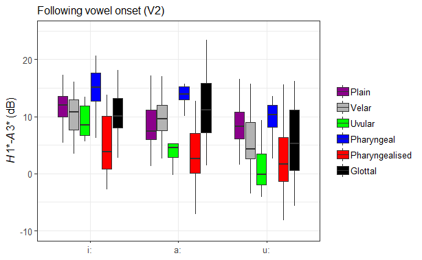

```r
gg.V2h1mnA3Box <- ggplot(dfPharRFSubV2,aes(y=predict(mdl.V2h1mnA3.Full),x=vowel,fill=context))+
  geom_boxplot(outlier.colour = "NA")+theme_bw()+
  labs(subtitle = "Following vowel onset (V2)",
       y=expression(paste(italic("H"),"1*-",italic("A"),"3* (dB)")))+
  theme(legend.title = element_blank(),
        legend.position = "right",legend.box = "horizontal") +
  coord_cartesian(ylim=c(-10,25))+
  theme(axis.title.x = element_blank())+
  guides(colour=guide_legend(override.aes=list(fill=NA),nrow = 1))+
  theme(text=element_text(size=12)) +
  scale_fill_manual(values = c("darkmagenta","gray70","green","blue","red","black"))
gg.V2h1mnA3Box
```

## 5.4 *A*1*-*A*3*

### 5.4.1 Model Specification

#### 5.4.1.1 Full Model

```r
mdl.V2A1mnA3.Full <- lmer(A1mnA3_01~context+vowel+Sex+(context+vowel||Speaker)+
                            (1|targetWord),data=dfPharRFSubV2,
                          control = lmerControl(optimizer = "bobyqa",optCtrl=list(maxfun=1e5)))
```

#### 5.4.1.2 Null Model

```r
mdl.V2A1mnA3.Null <- lmer(A1mnA3_01~vowel+Sex+(vowel||Speaker)+
                            (1|targetWord),data=dfPharRFSubV2,
                          control = lmerControl(optimizer = "bobyqa",optCtrl=list(maxfun=1e5)))
```

### 5.4.2 Model Comparison

```r
anova(mdl.V2A1mnA3.Null,mdl.V2A1mnA3.Full)
```

```
Data: dfPharRFSubV2
Models:
mdl.V2A1mnA3.Null: A1mnA3_01 ~ vowel + Sex + (vowel || Speaker) + (1 | targetWord)
mdl.V2A1mnA3.Full: A1mnA3_01 ~ context + vowel + Sex + (context + vowel || Speaker) +
mdl.V2A1mnA3.Full:     (1 | targetWord)
                  Df   AIC   BIC  logLik deviance  Chisq Chi Df
mdl.V2A1mnA3.Null 13 12733 12806 -6353.6    12707
mdl.V2A1mnA3.Full 39 12613 12832 -6267.6    12535 172.07     26
                  Pr(>Chisq)
mdl.V2A1mnA3.Null
mdl.V2A1mnA3.Full  < 2.2e-16 ***
---
Signif. codes:  0 ‘***’ 0.001 ‘**’ 0.01 ‘*’ 0.05 ‘.’ 0.1 ‘ ’ 1
```

### 5.4.3 Summary

```r
summary(mdl.V2A1mnA3.Full)
```

```
Linear mixed model fit by REML. t-tests use Satterthwaite's
  method [lmerModLmerTest]
Formula:
A1mnA3_01 ~ context + vowel + Sex + (context + vowel || Speaker) +
    (1 | targetWord)
   Data: dfPharRFSubV2
Control:
lmerControl(optimizer = "bobyqa", optCtrl = list(maxfun = 1e+05))

REML criterion at convergence: 12515.2

Scaled residuals:
    Min      1Q  Median      3Q     Max
-4.2472 -0.6205 -0.0062  0.6118  3.5608

Random effects:
 Groups     Name                  Variance Std.Dev. Corr
 targetWord (Intercept)            6.3991  2.5296
 Speaker    voweli:               12.9479  3.5983
            vowela:                2.5765  1.6052   -0.13
            vowelu:                9.1354  3.0225    0.61 -0.51
 Speaker.1  contextPlain           0.0000  0.0000
            contextVelar           1.4947  1.2226     NaN
            contextUvular          5.6210  2.3709     NaN  0.19
            contextPharyngeal      2.9268  1.7108     NaN -0.13
            contextPharyngealised  9.4335  3.0714     NaN  0.07
            contextGlottal         0.6342  0.7964     NaN  0.22
 Speaker.2  (Intercept)            3.8553  1.9635
 Residual                         24.2262  4.9220








  0.56
  0.51  0.24
 -0.03 -0.09 -0.86
```

[output cut: 35 more lines]

```
vowela:       -0.665  0.000  0.000  0.000         0.000
vowelu:       -0.465  0.000  0.000  0.000         0.001
SexMale       -0.434  0.000  0.000  0.000         0.000
              cntxtG vowela: vowelu:
contextVelr
contextUvlr
contxtPhryngl
cntxtPhryngls
contxtGlttl
vowela:        0.000
vowelu:        0.000  0.411
SexMale        0.000  0.000   0.000
convergence code: 0
unable to evaluate scaled gradient
Model failed to converge: degenerate  Hessian with 1 negative eigenvalues
```

### 5.4.4 Pairwise comparison

```r
pairwise.t.test(predict(mdl.V2A1mnA3.Full),
                dfPharRFSubV2$context:dfPharRFSubV2$vowel, p.adj = "fdr")
```

```
    Pairwise comparisons using t tests with pooled SD

data:  predict(mdl.V2A1mnA3.Full) and dfPharRFSubV2$context:dfPharRFSubV2$vowel

                  Plain:i: Plain:a: Plain:u: Velar:i: Velar:a:
Plain:a:          < 2e-16  -        -        -        -
Plain:u:          8.4e-12  5.6e-09  -        -        -
Velar:i:          0.01095  < 2e-16  0.00115  -        -
Velar:a:          < 2e-16  0.89106  1.4e-06  7.3e-13  -
Velar:u:          < 2e-16  0.11589  3.6e-11  < 2e-16  0.12918
Uvular:i:         0.00259  0.00154  0.75884  0.14327  0.00310
Uvular:a:         < 2e-16  8.4e-12  < 2e-16  < 2e-16  3.6e-11
Uvular:u:         < 2e-16  2.7e-08  < 2e-16  < 2e-16  6.7e-08
Pharyngeal:i:     0.33972  < 2e-16  1.9e-08  0.00545  < 2e-16
Pharyngeal:a:     7.6e-15  0.60963  0.00115  6.4e-08  0.70358
Pharyngeal:u:     0.10984  2.1e-11  0.00442  0.76252  9.1e-10
Pharyngealised:i: < 2e-16  0.65505  2.5e-07  2.4e-14  0.79527
Pharyngealised:a: < 2e-16  < 2e-16  < 2e-16  < 2e-16  6.3e-16
Pharyngealised:u: < 2e-16  < 2e-16  < 2e-16  < 2e-16  1.9e-15
Glottal:i:        0.32165  2.9e-13  0.00057  0.39792  2.4e-11
Glottal:a:        < 2e-16  0.00154  2.0e-12  < 2e-16  0.00243
Glottal:u:        2.2e-11  0.10863  0.03262  1.3e-05  0.16221
                  Velar:u: Uvular:i: Uvular:a: Uvular:u:
Plain:a:          -        -         -         -
Plain:u:          -        -         -         -
Velar:i:          -        -         -         -
Velar:a:          -        -         -         -
Velar:u:          -        -         -         -
Uvular:i:         8.2e-05  -         -         -
Uvular:a:         1.6e-08  4.3e-14   -         -
Uvular:u:         9.6e-06  3.7e-11   0.39155   -
Pharyngeal:i:     < 2e-16  0.00101   < 2e-16   < 2e-16
Pharyngeal:a:     0.10678  0.01658   2.9e-10   2.0e-07
Pharyngeal:u:     1.6e-13  0.12107   < 2e-16   < 2e-16
Pharyngealised:i: 0.05246  0.00367   2.3e-12   8.8e-09
Pharyngealised:a: 1.1e-10  4.5e-15   0.04548   0.41866
Pharyngealised:u: 2.1e-10  5.7e-15   0.04972   0.43358
Glottal:i:        2.2e-15  0.05246   < 2e-16   < 2e-16
Glottal:a:        0.07475  1.1e-06   0.00015   0.00656
Glottal:u:        0.00783  0.09651   2.2e-12   3.2e-09
```

[output cut: 41 more lines]

```
Velar:u:          -                 -          -
Uvular:i:         -                 -          -
Uvular:a:         -                 -          -
Uvular:u:         -                 -          -
Pharyngeal:i:     -                 -          -
Pharyngeal:a:     -                 -          -
Pharyngeal:u:     -                 -          -
Pharyngealised:i: -                 -          -
Pharyngealised:a: -                 -          -
Pharyngealised:u: -                 -          -
Glottal:i:        < 2e-16           -          -
Glottal:a:        0.00267           < 2e-16    -
Glottal:u:        8.1e-15           6.3e-06    0.00011

P value adjustment method: fdr
```

### 5.4.5 Figure

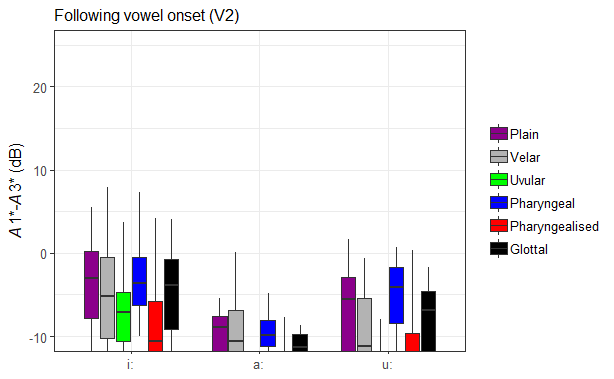

```r
gg.V2A1mnA3Box <- ggplot(dfPharRFSubV2,aes(y=predict(mdl.V2A1mnA3.Full),x=vowel,fill=context))+
  geom_boxplot(outlier.colour = "NA")+theme_bw()+
  labs(subtitle = "Following vowel onset (V2)",
       y=expression(paste(italic("A"),"1*-",italic("A"),"3* (dB)")))+
  theme(legend.title = element_blank(),
        legend.position = "right",legend.box = "horizontal") +
  coord_cartesian(ylim=c(-10,25))+
  theme(axis.title.x = element_blank())+
  guides(colour=guide_legend(override.aes=list(fill=NA),nrow = 1))+
  theme(text=element_text(size=12)) +
  scale_fill_manual(values = c("darkmagenta","gray70","green","blue","red","black"))
gg.V2A1mnA3Box
```

## 5.5 *A*2*-*A*3*

### 5.5.1 Model Specification

#### 5.5.1.1 Full Model

```r
mdl.V2A2mnA3.Full <- lmer(A2mnA3_01~context+vowel+Sex+(context+vowel||Speaker)+
                            (1|targetWord),data=dfPharRFSubV2,
                          control = lmerControl(optimizer = "bobyqa",optCtrl=list(maxfun=1e5)))
```

#### 5.5.1.2 Null Model

```r
mdl.V2A2mnA3.Null <- lmer(A2mnA3_01~vowel+Sex+(vowel||Speaker)+
                            (1|targetWord),data=dfPharRFSubV2,
                          control = lmerControl(optimizer = "bobyqa",optCtrl=list(maxfun=1e5)))
```

### 5.5.2 Model Comparison

```r
anova(mdl.V2A2mnA3.Null,mdl.V2A2mnA3.Full)
```

```
Data: dfPharRFSubV2
Models:
mdl.V2A2mnA3.Null: A2mnA3_01 ~ vowel + Sex + (vowel || Speaker) + (1 | targetWord)
mdl.V2A2mnA3.Full: A2mnA3_01 ~ context + vowel + Sex + (context + vowel || Speaker) +
mdl.V2A2mnA3.Full:     (1 | targetWord)
                  Df   AIC   BIC  logLik deviance  Chisq Chi Df
mdl.V2A2mnA3.Null 13 13136 13209 -6554.8    13110
mdl.V2A2mnA3.Full 39 12974 13193 -6447.9    12896 213.84     26
                  Pr(>Chisq)
mdl.V2A2mnA3.Null
mdl.V2A2mnA3.Full  < 2.2e-16 ***
---
Signif. codes:  0 ‘***’ 0.001 ‘**’ 0.01 ‘*’ 0.05 ‘.’ 0.1 ‘ ’ 1
```

### 5.5.3 Summary

```r
summary(mdl.V2A2mnA3.Full)
```

```
Linear mixed model fit by REML. t-tests use Satterthwaite's
  method [lmerModLmerTest]
Formula:
A2mnA3_01 ~ context + vowel + Sex + (context + vowel || Speaker) +
    (1 | targetWord)
   Data: dfPharRFSubV2
Control:
lmerControl(optimizer = "bobyqa", optCtrl = list(maxfun = 1e+05))

REML criterion at convergence: 12877.3

Scaled residuals:
    Min      1Q  Median      3Q     Max
-3.5228 -0.5739 -0.0032  0.6003  5.3752

Random effects:
 Groups     Name                  Variance Std.Dev. Corr
 targetWord (Intercept)           10.3505  3.2172
 Speaker    voweli:               13.1791  3.6303
            vowela:                0.8969  0.9470    0.50
            vowelu:                2.2049  1.4849   -0.30 -0.98
 Speaker.1  contextPlain           1.7333  1.3166
            contextVelar           0.9789  0.9894   -0.23
            contextUvular          4.9919  2.2343   -0.11 -0.12
            contextPharyngeal      1.2521  1.1190    0.06 -0.80
            contextPharyngealised  8.7069  2.9507   -0.43 -0.21
            contextGlottal         2.4702  1.5717    0.69  0.02
 Speaker.2  (Intercept)            0.0000  0.0000
 Residual                         29.1865  5.4025








 -0.47
  0.26  0.12
 -0.42  0.09 -0.92
```

[output cut: 35 more lines]

```
vowela:       -0.740  0.000  0.000  0.000         0.000
vowelu:       -0.756  0.000  0.000  0.000         0.000
SexMale       -0.119  0.001 -0.001  0.001         0.000
              cntxtG vowela: vowelu:
contextVelr
contextUvlr
contxtPhryngl
cntxtPhryngls
contxtGlttl
vowela:        0.000
vowelu:        0.000  0.685
SexMale        0.000 -0.002  -0.001
convergence code: 0
unable to evaluate scaled gradient
Model failed to converge: degenerate  Hessian with 1 negative eigenvalues
```

### 5.5.4 Pairwise comparison

```r
pairwise.t.test(predict(mdl.V2A2mnA3.Full),
                dfPharRFSubV2$context:dfPharRFSubV2$vowel, p.adj = "fdr")
```

```
    Pairwise comparisons using t tests with pooled SD

data:  predict(mdl.V2A2mnA3.Full) and dfPharRFSubV2$context:dfPharRFSubV2$vowel

                  Plain:i: Plain:a: Plain:u: Velar:i: Velar:a:
Plain:a:          < 2e-16  -        -        -        -
Plain:u:          < 2e-16  1.6e-10  -        -        -
Velar:i:          6.5e-08  < 2e-16  < 2e-16  -        -
Velar:a:          < 2e-16  6.2e-06  < 2e-16  < 2e-16  -
Velar:u:          < 2e-16  < 2e-16  < 2e-16  < 2e-16  < 2e-16
Uvular:i:         < 2e-16  0.77673  0.00058  < 2e-16  0.02560
Uvular:a:         < 2e-16  1.8e-10  0.00148  < 2e-16  < 2e-16
Uvular:u:         < 2e-16  < 2e-16  < 2e-16  < 2e-16  < 2e-16
Pharyngeal:i:     0.00033  < 2e-16  < 2e-16  0.55709  < 2e-16
Pharyngeal:a:     < 2e-16  6.1e-07  < 2e-16  < 2e-16  0.17174
Pharyngeal:u:     < 2e-16  2.4e-06  0.63221  < 2e-16  3.0e-14
Pharyngealised:i: < 2e-16  < 2e-16  0.00038  < 2e-16  < 2e-16
Pharyngealised:a: < 2e-16  < 2e-16  < 2e-16  < 2e-16  < 2e-16
Pharyngealised:u: < 2e-16  < 2e-16  < 2e-16  < 2e-16  < 2e-16
Glottal:i:        0.00566  < 2e-16  < 2e-16  1.1e-10  < 2e-16
Glottal:a:        < 2e-16  0.46174  6.2e-07  < 2e-16  0.01107
Glottal:u:        < 2e-16  < 2e-16  < 2e-16  < 2e-16  < 2e-16
                  Velar:u: Uvular:i: Uvular:a: Uvular:u:
Plain:a:          -        -         -         -
Plain:u:          -        -         -         -
Velar:i:          -        -         -         -
Velar:a:          -        -         -         -
Velar:u:          -        -         -         -
Uvular:i:         < 2e-16  -         -         -
Uvular:a:         2.2e-07  5.5e-07   -         -
Uvular:u:         9.6e-10  < 2e-16   < 2e-16   -
Pharyngeal:i:     < 2e-16  < 2e-16   < 2e-16   < 2e-16
Pharyngeal:a:     < 2e-16  0.00268   < 2e-16   < 2e-16
Pharyngeal:u:     < 2e-16  0.00089   0.01492   < 2e-16
Pharyngealised:i: < 2e-16  1.9e-07   0.18814   < 2e-16
Pharyngealised:a: 5.1e-05  < 2e-16   0.00285   < 2e-16
Pharyngealised:u: < 2e-16  < 2e-16   < 2e-16   0.76922
Glottal:i:        < 2e-16  < 2e-16   < 2e-16   < 2e-16
Glottal:a:        < 2e-16  0.80468   1.5e-09   < 2e-16
Glottal:u:        0.00943  < 2e-16   0.00429   1.7e-13
```

[output cut: 41 more lines]

```
Velar:u:          -                 -          -
Uvular:i:         -                 -          -
Uvular:a:         -                 -          -
Uvular:u:         -                 -          -
Pharyngeal:i:     -                 -          -
Pharyngeal:a:     -                 -          -
Pharyngeal:u:     -                 -          -
Pharyngealised:i: -                 -          -
Pharyngealised:a: -                 -          -
Pharyngealised:u: -                 -          -
Glottal:i:        < 2e-16           -          -
Glottal:a:        < 2e-16           < 2e-16    -
Glottal:u:        < 2e-16           < 2e-16    < 2e-16

P value adjustment method: fdr
```

### 5.5.5 Figure

[figure not shown]

```r
gg.V2A2mnA3Box <- ggplot(dfPharRFSubV2,aes(y=predict(mdl.V2A2mnA3.Full),x=vowel,fill=context))+
  geom_boxplot(outlier.colour = "NA")+theme_bw()+
  labs(subtitle = "Following vowel onset (V2)",
       y=expression(paste(italic("A"),"1*-",italic("A"),"3* (dB)")))+
  theme(legend.title = element_blank(),
        legend.position = "right",legend.box = "horizontal") +
  coord_cartesian(ylim=c(-10,25))+
  theme(axis.title.x = element_blank())+
  guides(colour=guide_legend(override.aes=list(fill=NA),nrow = 1))+
  theme(text=element_text(size=12)) +
  scale_fill_manual(values = c("darkmagenta","gray70","green","blue","red","black"))
gg.V2A2mnA3Box
```

# 6 Principal Component Analyses

We use the Principal Component Analyses as a data reduction technique to evaluate the groupings in the data and the contribution of predictors to the differences

## 6.1 Data manipulation

### 6.1.1 Subset of the data

```r
dfPharRFCluster <- select(dfPharRFV2.O,
                               "Label","context",
                               "CPP_01","Energy_01",
                               "H1A1c_01",
                               "H1A2c_01",
                               "H1A3c_01","H1H2c_01",
                               "H2H4c_01",
                               "H2KH5Kc_01",
                               "H42Kc_01","HNR05_01",
                               "HNR15_01",
                               "HNR25_01",
                               "HNR35_01",
                               "SHR_01","soe_01",
                               "Z1mnZ0_01",
                               "Z2mnZ1_01","Z3mnZ2_01",
                               "A1mnA2_01",
                               "A1mnA3_01","A2mnA3_01")
dfPharRFCluster
```

[output not shown]

[output cut: 990 more lines]

```r
dfPharRFCluster <- subset(dfPharRFCluster,Label=="V2")
dfPharRFCluster <- dfPharRFCluster[,-1]
str(dfPharRFCluster)
```

```
'data.frame':   2034 obs. of  22 variables:
 $ context   : Factor w/ 6 levels "Plain","Velar",..: 1 1 1 1 1 1 5 5 5 5 ...
 $ CPP_01    : num  22.9 22.2 20.6 16 22.6 ...
 $ Energy_01 : num  5.56 8.38 4.77 4.89 5.71 ...
 $ H1A1c_01  : num  19.6 17.1 18.7 20.8 18.2 ...
 $ H1A2c_01  : num  20.5 16 16 18.9 12.7 ...
 $ H1A3c_01  : num  9.8 7.54 10.61 12.98 5.92 ...
 $ H1H2c_01  : num  1.255 -0.016 -1.433 2.634 0.974 ...
 $ H2H4c_01  : num  7.64 3.67 7.72 8.74 12.25 ...
 $ H2KH5Kc_01: num  19.7 12.8 11.6 16.2 20.5 ...
 $ H42Kc_01  : num  2.83 8.1 7.58 3.32 -3.61 ...
 $ HNR05_01  : num  22.26 17.85 16.34 1.24 4.3 ...
 $ HNR15_01  : num  19.94 16.52 15.28 6.89 11.87 ...
 $ HNR25_01  : num  24.4 19.3 18.5 11.8 14.9 ...
 $ HNR35_01  : num  24.8 19.2 20.5 14 15.3 ...
 $ SHR_01    : num  0 0.188 0 0.199 0.672 0.08 0 0 0.1 0 ...
 $ soe_01    : num  0.054 0.055 0.043 0.054 0.054 0.061 0.073 0.058 0.058 0.061 ...
 $ Z1mnZ0_01 : num  4.85 4.41 4.53 4.21 3.92 ...
 $ Z2mnZ1_01 : num  5.22 5.57 5.61 6.11 6.43 ...
 $ Z3mnZ2_01 : num  4.35 4.21 3.93 4.08 3.74 ...
 $ A1mnA2_01 : num  0.913 -1.136 -2.764 -1.913 -5.492 ...
 $ A1mnA3_01 : num  -9.77 -9.57 -8.13 -7.83 -12.24 ...
 $ A2mnA3_01 : num  -10.68 -8.44 -5.37 -5.92 -6.75 ...
```

### 6.1.2 Rotating the data

```r
meltdfPharRFCluster <- melt(dfPharRFCluster, id="context")
meltdfPharRFCluster$seq <- with(meltdfPharRFCluster, ave(value, context, variable, FUN = seq_along))
meltdfPharRFCluster <- dcast(variable + seq ~ context, data = meltdfPharRFCluster, value.var = "value")
meltdfPharRFCluster <- meltdfPharRFCluster[,-2]
str(meltdfPharRFCluster)
```

```
'data.frame':   13545 obs. of  7 variables:
 $ variable      : Factor w/ 21 levels "CPP_01","Energy_01",..: 1 1 1 1 1 1 1 1 1 1 ...
 $ Plain         : num  22.9 22.2 20.6 16 22.6 ...
 $ Velar         : num  21.9 24 22.5 22 26 ...
 $ Uvular        : num  23.3 22.8 24.3 18.1 16.5 ...
 $ Pharyngeal    : num  25.7 24.2 26.8 27.4 27.2 ...
 $ Pharyngealised: num  23.9 25.5 20 17.3 24.6 ...
 $ Glottal       : num  20.5 19.8 22.3 20.2 22.6 ...
```

### 6.1.3 Central Imputations

```r
meltdfPharRFCluster[, 3:7] <- centralImputation(meltdfPharRFCluster[, 3:7])
```

## 6.2 Running our PCA

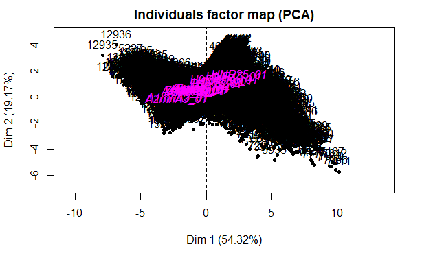

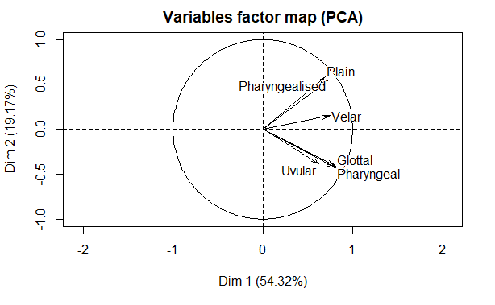

```r
pcaV2 <- PCA(meltdfPharRFCluster[, 1:7],
             scale.unit = TRUE, graph = TRUE,quali.sup = 1) # graphs generated automatically
```

## 6.3 Results

### 6.3.1 Summary

```r
summary(pcaV2)
```

```
Call:
PCA(X = meltdfPharRFCluster[, 1:7], scale.unit = TRUE, quali.sup = 1,
     graph = TRUE)


Eigenvalues
                       Dim.1   Dim.2   Dim.3   Dim.4   Dim.5
Variance               3.259   1.150   0.617   0.519   0.282
% of var.             54.324  19.169  10.290   8.657   4.700
Cumulative % of var.  54.324  73.493  83.783  92.440  97.140
                       Dim.6
Variance               0.172
% of var.              2.860
Cumulative % of var. 100.000

Individuals (the 10 first)
                   Dist    Dim.1    ctr   cos2    Dim.2    ctr
1              |  4.163 |  3.786  0.032  0.827 | -1.280  0.011
2              |  4.057 |  3.736  0.032  0.848 | -1.093  0.008
3              |  4.361 |  3.857  0.034  0.782 | -1.694  0.018
4              |  3.587 |  3.197  0.023  0.794 | -1.531  0.015
5              |  3.886 |  3.747  0.032  0.930 | -0.986  0.006
6              |  3.480 |  3.155  0.023  0.822 | -1.131  0.008
7              |  3.425 |  3.251  0.024  0.901 | -0.908  0.005
8              |  3.419 |  3.268  0.024  0.914 | -0.808  0.004
9              |  4.634 |  4.151  0.039  0.802 | -1.831  0.022
10             |  3.984 |  3.536  0.028  0.788 | -0.771  0.004
                 cos2    Dim.3    ctr   cos2
1               0.095 |  1.106  0.015  0.071 |
2               0.073 |  1.114  0.015  0.075 |
3               0.151 |  1.100  0.014  0.064 |
4               0.182 |  0.251  0.001  0.005 |
5               0.064 | -0.062  0.000  0.000 |
6               0.106 |  0.557  0.004  0.026 |
7               0.070 | -0.020  0.000  0.000 |
8               0.056 |  0.310  0.001  0.008 |
9               0.156 |  0.895  0.010  0.037 |
10              0.038 |  1.345  0.022  0.114 |

Variables
```

[output cut: 23 more lines]

```
H2H4c_01       |   0.736 |  -0.674   0.840  -9.720 |  -0.260
H2KH5Kc_01     |   1.502 |   1.376   0.840  19.837 |   0.546
H42Kc_01       |   1.253 |  -1.178   0.883 -16.977 |  -0.367
HNR05_01       |   1.506 |   1.425   0.895  20.536 |   0.444
                  cos2  v.test     Dim.3    cos2  v.test
CPP_01           0.111   9.835 |   0.013   0.000   0.422 |
Energy_01        0.122  -3.159 |   0.031   0.007   1.016 |
H1A1c_01         0.071   5.107 |   0.007   0.000   0.241 |
H1A2c_01         0.109   7.804 |   0.065   0.004   2.148 |
H1A3c_01         0.254  -5.010 |  -0.114   0.077  -3.767 |
H1H2c_01         0.113  -5.191 |   0.024   0.001   0.788 |
H2H4c_01         0.125  -6.319 |   0.006   0.000   0.204 |
H2KH5Kc_01       0.132  13.259 |   0.130   0.008   4.312 |
H42Kc_01         0.086  -8.906 |  -0.042   0.001  -1.397 |
HNR05_01         0.087  10.779 |  -0.051   0.001  -1.696 |
```

### 6.3.2 Contribution of predictors and groups

```r
dimdesc(pcaV2, axes = 1:4, proba = 0.05)
```

```
$`Dim.1`
$`Dim.1`$`quanti`
               correlation p.value
Pharyngeal       0.8071268       0
Glottal          0.8059345       0
Velar            0.7474932       0
Pharyngealised   0.7288070       0
Plain            0.6917016       0
Uvular           0.6245731       0

$`Dim.1`$quali
                R2 p.value
variable 0.6015926       0

$`Dim.1`$category
             Estimate       p.value
HNR25_01    2.5320016 7.811194e-307
HNR35_01    2.5171658 4.373106e-303
HNR15_01    2.0963412 1.474607e-207
HNR05_01    1.4247503  3.612615e-95
H2KH5Kc_01  1.3762065  7.889468e-89
CPP_01      1.1421790  1.715623e-61
H1A2c_01    0.9028825  5.991906e-39
H1A1c_01    0.7624988  3.244412e-28
H1A3c_01   -0.2510478  2.953985e-04
Energy_01  -0.2864487  3.628095e-05
Z2mnZ1_01  -0.4776854  5.537842e-12
H1H2c_01   -0.5909411  1.478070e-17
Z3mnZ2_01  -0.6693065  4.306745e-22
H2H4c_01   -0.6743088  2.116690e-22
Z1mnZ0_01  -0.8508780  9.259542e-35
A1mnA2_01  -1.0156211  6.751888e-49
SHR_01     -1.1327680  1.672571e-60
soe_01     -1.1477188  4.449482e-62
H42Kc_01   -1.1778225  2.582479e-65
A1mnA3_01  -2.1695492 1.018411e-222
A2mnA3_01  -2.3099299 1.756805e-253


$Dim.2
```

[output cut: 68 more lines]

```
Pharyngeal      0.11488922  4.982505e-41
Uvular          0.02607255  2.408252e-03
Velar          -0.64261634  0.000000e+00

$Dim.4$quali
                  R2     p.value
variable 0.003176072 0.002013341

$Dim.4$category
             Estimate     p.value
HNR05_01   0.08548506 0.002021169
Energy_01  0.06721532 0.015217134
CPP_01     0.05437931 0.049578479
A1mnA3_01 -0.05740792 0.038176027
A2mnA3_01 -0.08740704 0.001596545
```

### 6.3.3 3-D plot

```r
coord <- pcaV2$var$coord[1:6,0]
coord
```

```
Plain
Velar
Uvular
Pharyngeal
Pharyngealised
Glottal
```

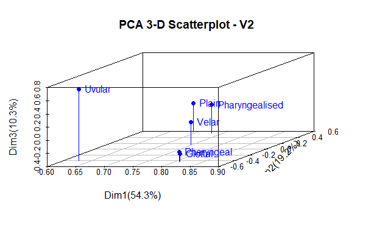

```r
#
with(pcaV2, {
  s3d <- scatterplot3d(pcaV2$var$coord[,1], pcaV2$var$coord[,2], pcaV2$var$coord[,3],        # x y and z axis
                       color="blue", pch=19,        # filled blue circles
                       type="h",                    # vertical lines to the x-y plane
                       main="PCA 3-D Scatterplot - V2",
                       xlab="Dim1(54.3%)",
                       ylab="",
                       zlab="Dim3(10.3%)")
  s3d.coords <- s3d$xyz.convert(pcaV2$var$coord[,1], pcaV2$var$coord[,2], pcaV2$var$coord[,3]) # convert 3D coords to 2D projection
  text(s3d.coords$x, s3d.coords$y,             # x and y coordinates
       labels=row.names(coord), col = "blue",              # text to plot
       cex=1, pos=4)           # shrink text 50% and place to right of points)
})
dims <- par("usr")
x <- dims[1]+ 0.8*diff(dims[1:2])
y <- dims[3]+ 0.08*diff(dims[3:4])
text(x, y, "Dim2(19.2%)", srt = 45,col="black")
```

# 7 Random Forest

## 7.1 Description

The patterns observed above show differences between the specific four categories: Plain, Uvular, Pharyngeal and Pharygealised as well as Velar and Glottal. We use Random Forests as a classification tool to evaluate the robustness of the observed differences and as a way to eliminate some of the correlates that do not contribute to the differences. We will grow several Random Forests as follows:

1. One Forest on V2 Onset with the six contexts. We will add the vowel specification to the 21 predictors
2. Another Forest similar to the first one but while adding the consonant ID as a way to increase the interactions within the dataframe. This will allow the forest to assign appropriate predictions to categories.

## 7.2 Creating training and testing datasets

```r
# creating training and testing sets
# we set the seeds for reproducibility
# for V2
set.seed(1)
train.idx <- sample(nrow(dfPharRFSubV2), 2/3 * nrow(dfPharRFSubV2))
PharV2.train <- dfPharRFSubV2[train.idx, ]
PharV2.test <- dfPharRFSubV2[-train.idx, ]
```

## 7.3 Model 1:

### 7.3.1 Model specification

```r
set.seed(1)
cforestPharV2.O.NoCons.train <- cforest(context~vowel+
                                 CPP_01_z+Energy_01_z+
                                 H1A1c_01_z+
                                 H1A2c_01_z+
                                 H1A3c_01_z+H1H2c_01_z+
                                 H2H4c_01_z+
                                 H2KH5Kc_01_z+
                                 H42Kc_01_z+HNR05_01_z+
                                 HNR15_01_z+
                                 HNR25_01_z+HNR35_01_z+SHR_01_z+
                                  soe_01_z+
                                 Z1mnZ0_01_z+Z2mnZ1_01_z+
                                   Z3mnZ2_01_z+A1mnA2_01_z+
                                   A1mnA3_01_z+A2mnA3_01_z,
                                       data = PharV2.train, control=cforest_unbiased(mtry=round(sqrt(23)),ntree=500))
# we use predict to obtain predictions from the training set on the testing set
cforestPharV2.O.NoCons.Test <- predict(cforestPharV2.O.NoCons.train, newdata = PharV2.test, OOB=TRUE, type = "response")
```

### 7.3.2 Percent correct and prediction table

```r
# Below is the predictions table showing the confusions
# Table predictions (rows) by original data (columns)
kable(round(prop.table(table(cforestPharV2.O.NoCons.Test,PharV2.test$context),2)*100,1))
```

|  | Plain | Velar | Uvular | Pharyngeal | Pharyngealised | Glottal |
| --- | --- | --- | --- | --- | --- | --- |
| Plain | 92.1 | 39.0 | 10.7 | 20.7 | 8.1 | 33.9 |
| Velar | 2.8 | 40.7 | 14.3 | 3.4 | 1.0 | 25.0 |
| Uvular | 0.0 | 0.0 | 0.0 | 0.0 | 0.5 | 0.0 |
| Pharyngeal | 0.5 | 1.6 | 10.7 | 51.7 | 1.0 | 1.8 |
| Pharyngealised | 4.7 | 17.1 | 60.7 | 20.7 | 88.9 | 10.7 |
| Glottal | 0.0 | 1.6 | 3.6 | 3.4 | 0.5 | 28.6 |

```r
# for percent correct
round((sum(PharV2.test$context==cforestPharV2.O.NoCons.Test)/nrow(PharV2.test))*100,2)
```

```
[1] 69.32
```

```r
# for correlations between our predictions and original data-frame
cor(as.numeric(cforestPharV2.O.NoCons.Test), as.numeric(PharV2.test$context))
```

```
[1] 0.6574896
```

## 7.4 Model 2:

### 7.4.1 Model specification

```r
set.seed(1)
cforestPharV2.O.Cons.train <- cforest(context~vowel+cons+
                                 CPP_01_z+Energy_01_z+
                                 H1A1c_01_z+
                                 H1A2c_01_z+
                                 H1A3c_01_z+H1H2c_01_z+
                                 H2H4c_01_z+
                                 H2KH5Kc_01_z+
                                 H42Kc_01_z+HNR05_01_z+
                                 HNR15_01_z+
                                 HNR25_01_z+HNR35_01_z+SHR_01_z+
                                  soe_01_z+
                                 Z1mnZ0_01_z+Z2mnZ1_01_z+
                                   Z3mnZ2_01_z+A1mnA2_01_z+
                                   A1mnA3_01_z+A2mnA3_01_z,
                                       data = PharV2.train, control=cforest_unbiased(mtry=round(sqrt(23)),ntree=500))
# we use predict to obtain predictions from the training set on the testing set
cforestPharV2.O.Cons.Test <- predict(cforestPharV2.O.Cons.train, newdata = PharV2.test, OOB=TRUE, type = "response")
```

### 7.4.2 Percent correct and prediction table

```r
# Below is the predictions table showing the confusions
# Below is the predictions table showing the confusions
# Table predictions (rows) by original data (columns)
kable(round(prop.table(table(cforestPharV2.O.Cons.Test,PharV2.test$context),2)*100,1))
```

|  | Plain | Velar | Uvular | Pharyngeal | Pharyngealised | Glottal |
| --- | --- | --- | --- | --- | --- | --- |
| Plain | 99.5 | 0 | 0.0 | 0 | 0 | 0 |
| Velar | 0.0 | 100 | 0.0 | 0 | 0 | 0 |
| Uvular | 0.0 | 0 | 92.9 | 0 | 0 | 0 |
| Pharyngeal | 0.0 | 0 | 7.1 | 100 | 0 | 0 |
| Pharyngealised | 0.5 | 0 | 0.0 | 0 | 100 | 0 |
| Glottal | 0.0 | 0 | 0.0 | 0 | 0 | 100 |

```r
# for percent correct
round((sum(PharV2.test$context==cforestPharV2.O.Cons.Test)/nrow(PharV2.test))*100,2)
```

```
[1] 99.56
```

```r
# for correlations between our predictions and original data-frame
cor(as.numeric(cforestPharV2.O.Cons.Test), as.numeric(PharV2.test$context))
```

```
[1] 0.9961493
```